# Soybean Analysis

Efoli Mathhew

15/06/2021

### Activities

1. Create a new Rstudio Project
2. Create and save a new analysis.Rmd file
3. Open the analysis.Rmd file and start working on it

## 4. Import the data from a google sheet (library gsheet). Give a name to the dataframe object (https://docs.google.com/spreadsheets/d/16BdPdimy6GYsrkahFiEM_y5Hy13D3psKfGJayBjVdNw/edit?usp=sharing )

```
## No encoding supplied: defaulting to UTF-8.
```

## 5. Check the structure of the data set (glimpse())

```
## Rows: 112
## Columns: 9
## $ study    <int> 424, 424, 424, 424, 424, 424, 424, 424, 424, 424, 424, 424, 4~
## $ year     <int> 2020, 2020, 2020, 2020, 2020, 2020, 2020, 2020, 2020, 2020, 2~
## $ location <chr> "CAMPO VERDE", "CAMPO VERDE", "CAMPO VERDE", "CAMPO VERDE", "~
## $ state    <chr> "MT", "MT", "MT", "MT", "MT", "MT", "MT", "MT", "MT", "MT", "~
## $ block    <int> 1, 2, 3, 4, 1, 2, 3, 4, 1, 2, 3, 4, 1, 2, 3, 4, 1, 2, 3, 4, 1~
## $ treat    <chr> "Aproach Prima", "Aproach Prima", "Aproach Prima", "Aproach P~
## $ ai       <chr> "picoxystrobin + cyproconazole", "picoxystrobin + cyproconazo~
## $ sev      <int> 28, 28, 47, 50, 38, 35, 45, 40, 55, 70, 72, 65, 37, 25, 27, 2~
## $ yld      <int> 3060, 3145, 3104, 3072, 3699, 3498, 3420, 3387, 2658, 2994, 3~
```

## 6. Save the data.frame as data.csv in the project directory

```r
write.csv(data,'data.csv')
```

## 7. Open the data in the data.csv file and assign to a new dataframe

```r
soybean <- data.frame(read.csv("data.csv", header = T))
head(soybean)
```

```
##   X study year    location state block         treat
## 1 1   424 2020 CAMPO VERDE    MT     1 Aproach Prima
## 2 2   424 2020 CAMPO VERDE    MT     2 Aproach Prima
## 3 3   424 2020 CAMPO VERDE    MT     3 Aproach Prima
## 4 4   424 2020 CAMPO VERDE    MT     4 Aproach Prima
## 5 5   424 2020 CAMPO VERDE    MT     1        Ativum
## 6 6   424 2020 CAMPO VERDE    MT     2        Ativum
##                                             ai sev  yld
## 1                picoxystrobin + cyproconazole  28 3060
## 2                picoxystrobin + cyproconazole  28 3145
## 3                picoxystrobin + cyproconazole  47 3104
## 4                picoxystrobin + cyproconazole  50 3072
## 5 epoxiconazole + fluxapiroxade+pyraclostrobin  38 3699
## 6 epoxiconazole + fluxapiroxade+pyraclostrobin  35 3498
```

## 8. Start exploring the data. First, subset the trials and create four different dataframes, one for each trial (there are four trials)

The Soybean data set is subset into 4 different data frames by trials.

```
## [1] "424" "425" "426" "427"
```

```
## 'data.frame':    112 obs. of  10 variables:
##  $ X       : int  1 2 3 4 5 6 7 8 9 10 ...
##  $ study   : int  424 424 424 424 424 424 424 424 424 424 ...
##  $ year    : int  2020 2020 2020 2020 2020 2020 2020 2020 2020 2020 ...
##  $ location: chr  "CAMPO VERDE" "CAMPO VERDE" "CAMPO VERDE" "CAMPO VERDE" ...
##  $ state   : chr  "MT" "MT" "MT" "MT" ...
##  $ block   : Factor w/ 4 levels "1","2","3","4": 1 2 3 4 1 2 3 4 1 2 ...
##  $ treat   : Factor w/ 7 levels "Aproach Prima",..: 1 1 1 1 2 2 2 2 3 3 ...
##  $ ai      : chr  "picoxystrobin + cyproconazole" "picoxystrobin + cyproconazole" "picoxystrobin + cyproconazole" "picoxystrobin + cyproconazole" ...
##  $ sev     : int  28 28 47 50 38 35 45 40 55 70 ...
##  $ yld     : int  3060 3145 3104 3072 3699 3498 3420 3387 2658 2994 ...
```

## 9. Produce plots to visualize the response variables

We have two response variables namely; yield and severity. We would present the yield and severity response variables using bar charts.

### Data Visualization for Trial 1

The table shows the soybean mean yield, standard deviation by treatment for trial 1. The mean of the blocks is estimated as the yield for each treatment.

```
##           treat     yld        sd
## 1 Aproach Prima 3095.25  38.01206
## 2        Ativum 3501.00 139.96428
## 3       Control 2925.25 180.15063
## 4        Elatus 3283.25 195.30382
## 5           FOX 3405.75 110.29166
## 6         Fusao 3445.50 155.22135
## 7      Vessarya 3247.25 226.84264
```

From the above table, Soybean treated with treatments, Ativum, Fusao, FOX have the highest average yield; 3501, 3445.50 and 3405.75 respectively.

```
##           treat   sev        sd
## 1 Aproach Prima 38.25 11.898879
## 2        Ativum 39.50  4.203173
## 3       Control 65.50  7.593857
## 4        Elatus 29.50  5.259911
## 5           FOX 33.50  3.415650
## 6         Fusao 29.50  8.346656
## 7      Vessarya 28.25  2.362908
```

From the above table, the control, and Soybean treated with treatments, Ativum, Aproach Prima have the highest average severity; 65.50, 39.50, 38.25 respectively.

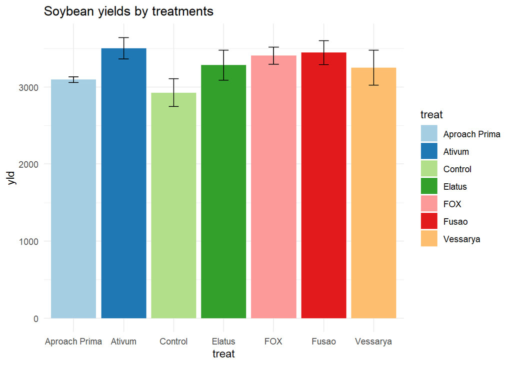

From the above chart, Soybean treated with treatments, Ativum, Fusao, FOX have the highest average yield; 3501, 3445.50 and 3405.75 respectively.

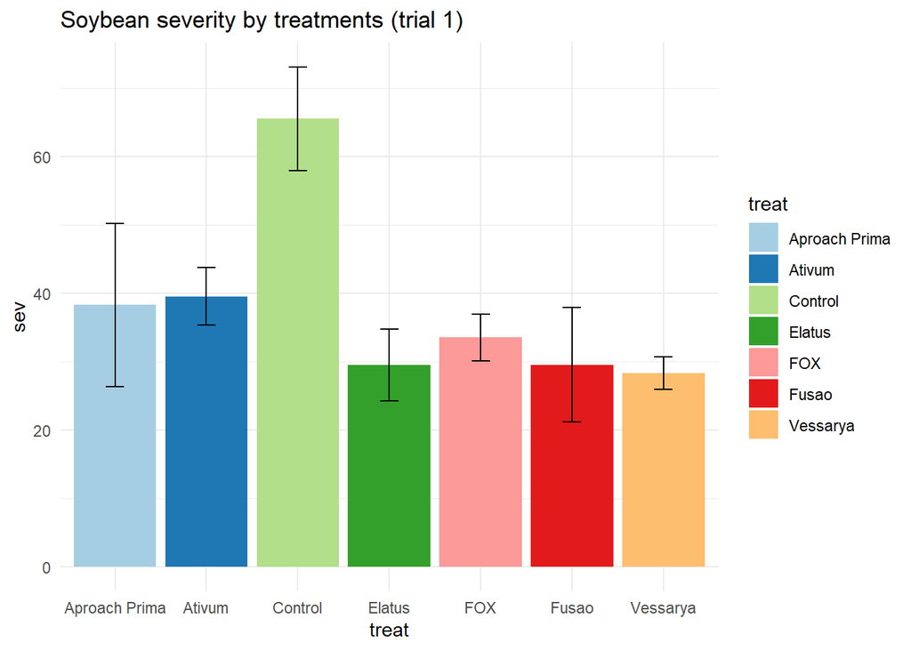

The chart above shows that the control, and Soybean treated with treatments, Ativum, Aproach Prima have the highest average severity; 65.50, 39.50, 38.25 respectively.

### Data visualization for trial 2

```
##           treat     yld       sd
## 1 Aproach Prima 4114.25 238.6872
## 2        Ativum 3995.75 121.5000
## 3       Control 4023.25 101.1645
## 4        Elatus 3912.25 223.6878
## 5           FOX 4157.25 291.1877
## 6         Fusao 4063.75 172.9824
## 7      Vessarya 4232.00 255.5113
```

```
##           treat   sev       sd
## 1 Aproach Prima  5.00 0.000000
## 2        Ativum  6.00 1.154701
## 3       Control 38.25 2.362908
## 4        Elatus  7.25 2.061553
## 5           FOX  5.00 1.632993
## 6         Fusao  6.75 2.362908
## 7      Vessarya  6.00 1.154701
```

The above table shows that Control(38.25) and treatments; Elatus(7.25) and Fusao(6.75) had the highest severity.

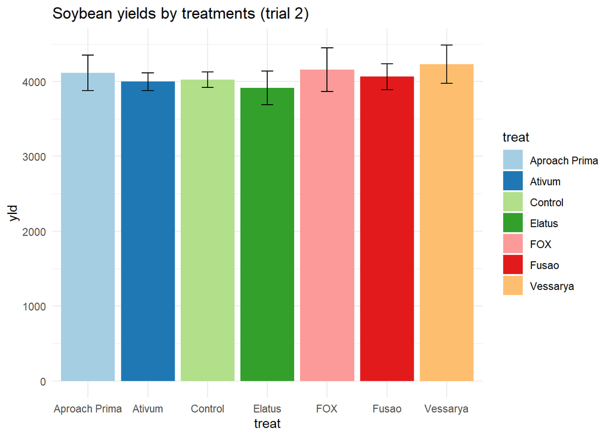

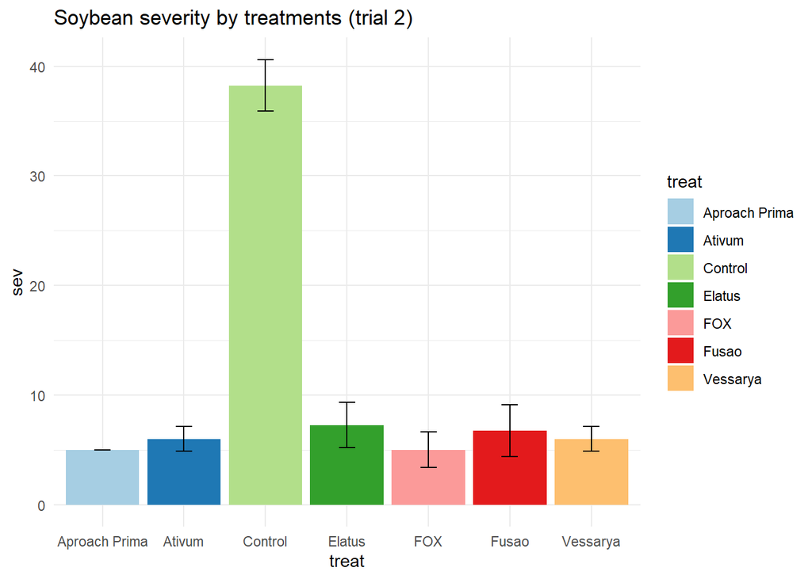

The above table shows that Control(38.25) and treatments; Elatus(7.25) and Fusao(6.75) had the highest severity.

### Data visualization for trial 3

```
##           treat     yld        sd
## 1 Aproach Prima 3720.00 444.60994
## 2        Ativum 3719.50 276.85917
## 3       Control 3404.25 501.13962
## 4        Elatus 3421.50 319.41666
## 5           FOX 3718.75  89.92358
## 6         Fusao 3708.75  49.07392
## 7      Vessarya 3790.25 390.76538
```

The above table shows that treatments; Vessarya(3790.25), Aproach Prima(3720.00) and Ativum (3719.50) had the highest yield.

```
##           treat   sev       sd
## 1 Aproach Prima 26.50 2.380476
## 2        Ativum 21.25 2.500000
## 3       Control 67.50 5.000000
## 4        Elatus 43.75 6.291529
## 5           FOX 20.00 4.082483
## 6         Fusao 22.50 8.660254
## 7      Vessarya 25.00 0.000000
```

The above table shows that Control(67.50) and treatments; Elatus(43.75) and Aproach Prima(26.50) had the highest severity.

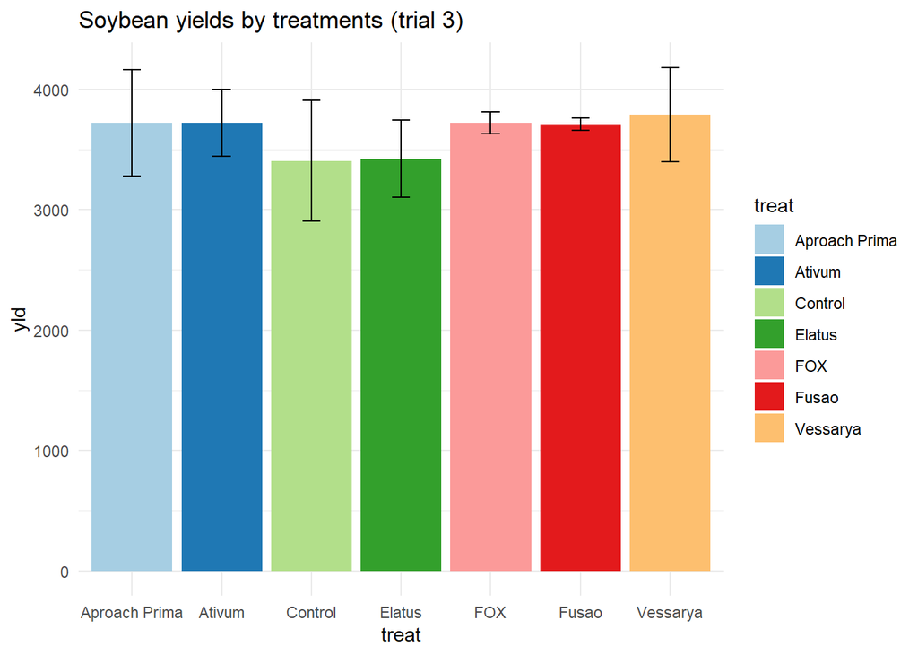

The above chart shows that treatments; Vessarya(3790.25), Aproach Prima(3720.00) and Ativum (3719.50) had the highest yield.

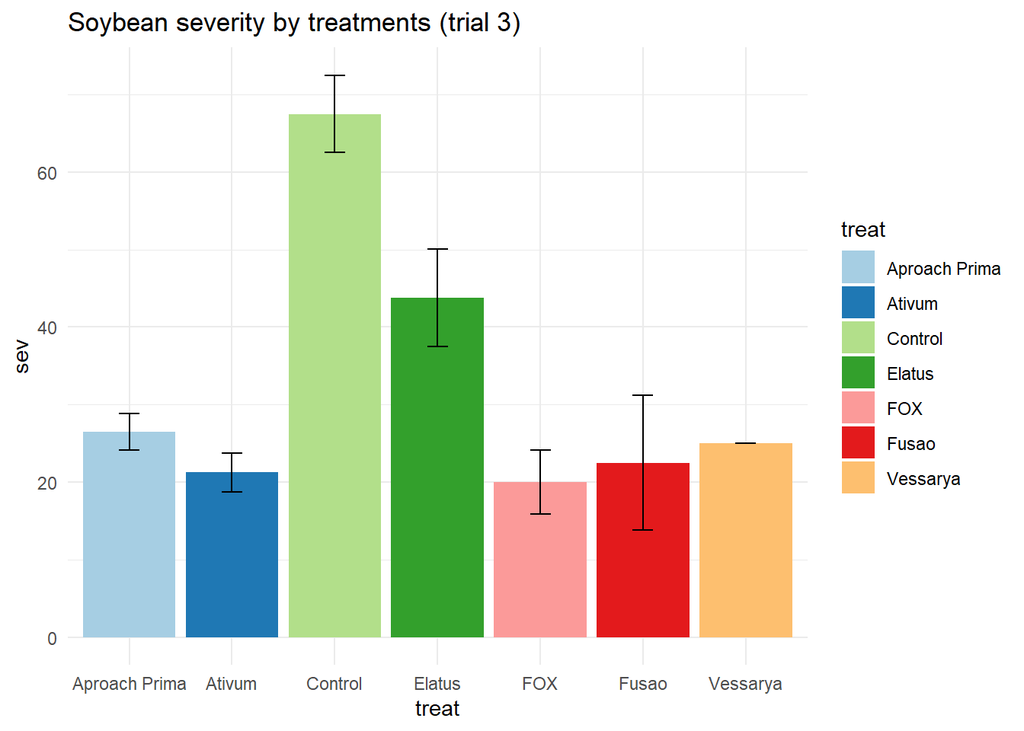

The above chart shows that Control(67.50) and treatments; Elatus(43.75) and Aproach Prima(26.50) had the highest severity.

### Data visualization for trial 4

```
##           treat     yld       sd
## 1 Aproach Prima 4133.75 211.1988
## 2        Ativum 4199.25 189.2113
## 3       Control 3363.00 215.0612
## 4        Elatus 3951.50 292.6722
## 5           FOX 4644.25 201.2550
## 6         Fusao 4155.25 467.4551
## 7      Vessarya 4130.00 344.1928
```

```
##           treat   sev        sd
## 1 Aproach Prima 37.00  6.271629
## 2        Ativum 35.75 10.904892
## 3       Control 93.75  2.500000
## 4        Elatus 68.75  6.291529
## 5           FOX 12.00  3.559026
## 6         Fusao 37.00  9.273618
## 7      Vessarya 47.00  6.271629
```

The above table shows that Control(93.75) and treatments; Elatus(68.75) and Vessarya(47.00) had the highest severity.

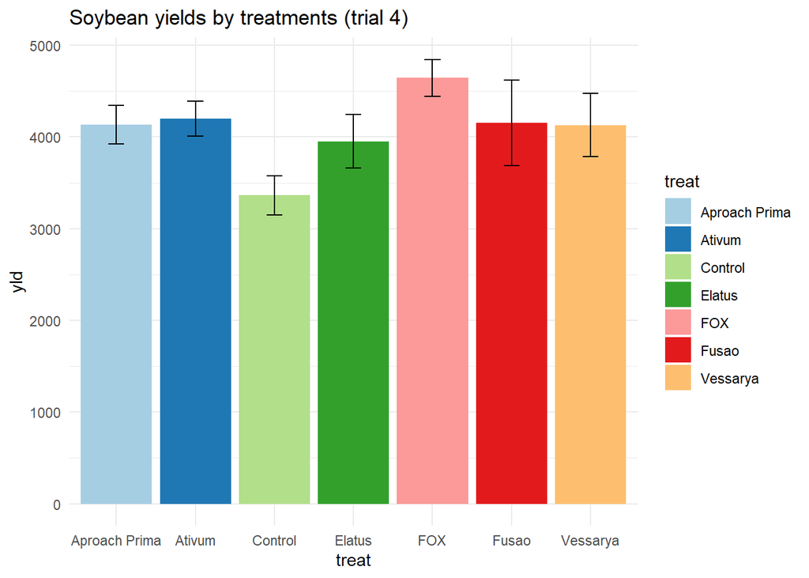

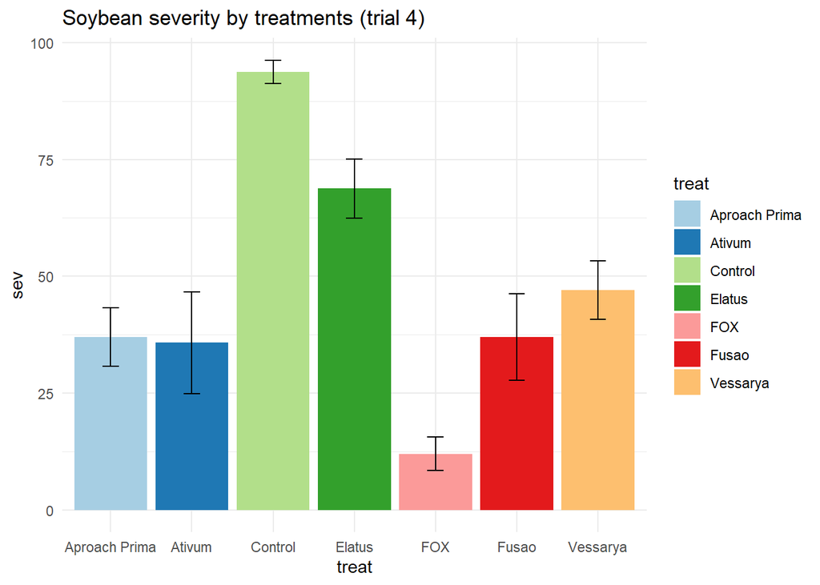

The above chart shows that Control(93.75) and treatments; Elatus(68.75) and Vessarya(47.00) had the highest severity.

## 10. Test hypotheses on the apparent effects for each trial

The one-way analysis of variance (ANOVA), also known as one-factor ANOVA, is an extension of independent two-samples t-test for comparing means in a situation where there are more than two groups. In one-way ANOVA, the data is organized into several groups base on one single grouping variable (also called factor variable). This tutorial describes the basic principle of the one-way ANOVA test and provides practical anova test examples in R software.

The one-way analysis of variance (ANOVA), also known as one-factor ANOVA, is an extension of independent two-samples t-test for comparing means in a situation where there are more than two groups. In one-way ANOVA, the data is organized into several groups base on one single grouping variable (also called factor variable). This tutorial describes the basic principle of the one-way ANOVA test and provides practical anova test examples in R software.

### Hypothesis testing for Trial 1

#### Hypothesis testing for yield (Trial 1)

Null hypothesis: the soybean yield means of the different treatments are the same.

Alternative hypothesis: At least one treatment means of the soybean yield is not equal to the others.

```
##
## Call:
## lm(formula = yld ~ treat, data = trl1)
##
## Coefficients:
##   (Intercept)    treatAtivum   treatControl    treatElatus       treatFOX
##        3095.2          405.8         -170.0          188.0          310.5
##    treatFusao  treatVessarya
##         350.3          152.0
```

```
## Analysis of Variance Table
##
## Response: yld
##           Df  Sum Sq Mean Sq F value   Pr(>F)
## treat      6 1010590  168432  6.5739 0.000507 ***
## Residuals 21  538045   25621
## ---
## Signif. codes:  0 '***' 0.001 '**' 0.01 '*' 0.05 '.' 0.1 ' ' 1
```

#### Hypothesis testing for severity (Trial 1)

Null Hypothesis: The treatments has no effects on the soybean severity.

Alternate Hypothesis: The treatments has effects on the soybean severity.

```
##
## Call:
## lm(formula = sev ~ treat, data = trl1)
##
## Coefficients:
##   (Intercept)    treatAtivum   treatControl    treatElatus       treatFOX
##         38.25           1.25          27.25          -8.75          -4.75
##    treatFusao  treatVessarya
##         -8.75         -10.00
```

```
## Analysis of Variance Table
##
## Response: sev
##           Df Sum Sq Mean Sq F value    Pr(>F)
## treat      6 4071.2  678.54  14.328 1.825e-06 ***
## Residuals 21  994.5   47.36
## ---
## Signif. codes:  0 '***' 0.001 '**' 0.01 '*' 0.05 '.' 0.1 ' ' 1
```

As the p-value is less than the significance level 0.001, we can conclude that there are significant differences between the groups highlighted with “***" in the anova table. We will also reject the null hypothesis which states The treatments has no effects on the soybean severity.

### Hypothesis testing for Trial 2

#### Hypothesis testing for yield (Trial 2)

Null hypothesis: the soybean yield means of the different treatments are the same.

Alternative hypothesis: At least one treatment means of the soybean yield is not equal to the others.

```
##
## Call:
## lm(formula = yld ~ treat, data = trl2)
##
## Coefficients:
##   (Intercept)    treatAtivum   treatControl    treatElatus       treatFOX
##        4114.3         -118.5          -91.0         -202.0           43.0
##    treatFusao  treatVessarya
##         -50.5          117.7
```

```
## Analysis of Variance Table
##
## Response: yld
##           Df Sum Sq Mean Sq F value Pr(>F)
## treat      6 273708   45618  1.0235 0.4374
## Residuals 21 936010   44572
```

As the p-value = 0.4374 which is greater than the significance level 0.05, we can conclude that there are no significant differences between the groups highlighted with “*" in the model summary. we will also accept the null hypothesis; the soybean yield means of the different treatments are the same.

#### Hypothesis testing for severity (Trial 2)

Null Hypothesis: The treatments has no effects on the soybean severity.

Alternate Hypothesis: The treatments has effects on the soybean severity.

```
##
## Call:
## lm(formula = sev ~ treat, data = trl2)
##
## Coefficients:
##   (Intercept)    treatAtivum   treatControl    treatElatus       treatFOX
##     5.000e+00      1.000e+00      3.325e+01      2.250e+00     -8.333e-15
##    treatFusao  treatVessarya
##     1.750e+00      1.000e+00
```

```
## Analysis of Variance Table
##
## Response: sev
##           Df Sum Sq Mean Sq F value    Pr(>F)
## treat      6 3582.4  597.07  201.42 < 2.2e-16 ***
## Residuals 21   62.2    2.96
## ---
## Signif. codes:  0 '***' 0.001 '**' 0.01 '*' 0.05 '.' 0.1 ' ' 1
```

As the p-value is less than the significance level 0.001, we can conclude that there are significant differences between the groups highlighted with “***" in the anova table. We will also reject the null hypothesis which states The treatments has no effects on the soybean severity.

### Hypothesis testing for Trial 3

#### Hypothesis testing for yield (Trial 3)

Null hypothesis: the soybean yield means of the different treatments are the same.

Alternative hypothesis: At least one treatment means of the soybean yield is not equal to the others.

```
##
## Call:
## lm(formula = yld ~ treat, data = trl3)
##
## Coefficients:
##   (Intercept)    treatAtivum   treatControl    treatElatus       treatFOX
##       3720.00          -0.50        -315.75        -298.50          -1.25
##    treatFusao  treatVessarya
##        -11.25          70.25
```

```
## Analysis of Variance Table
##
## Response: yld
##           Df  Sum Sq Mean Sq F value Pr(>F)
## treat      6  598170   99695  0.8826 0.5246
## Residuals 21 2372067  112956
```

As the p-value = 0.5246 which is greater than the significance level 0.05, we can conclude that there are no significant differences between the groups highlighted with “*" in the model summary.Therefore, we will also accept the null hypothesis; the soybean yield means of the different treatments are the same.

#### Hypothesis testing for severity (Trial 3)

Null Hypothesis: The treatments has no effects on the soybean severity.

Alternate Hypothesis: The treatments has effects on the soybean severity.

```
##
## Call:
## lm(formula = sev ~ treat, data = trl3)
##
## Coefficients:
##   (Intercept)    treatAtivum   treatControl    treatElatus       treatFOX
##         26.50          -5.25          41.00          17.25          -6.50
##    treatFusao  treatVessarya
##         -4.00          -1.50
```

```
## Analysis of Variance Table
##
## Response: sev
##           Df Sum Sq Mean Sq F value    Pr(>F)
## treat      6 7305.9 1217.65  50.685 2.045e-11 ***
## Residuals 21  504.5   24.02
## ---
## Signif. codes:  0 '***' 0.001 '**' 0.01 '*' 0.05 '.' 0.1 ' ' 1
```

As the p-value is less than the significance level 0.001, we can conclude that there are significant differences between the groups highlighted with “***" in the anova table. We will also reject the null hypothesis which states The treatments has no effects on the soybean severity.

### Hypothesis testing for Trial 4

#### Hypothesis testing for yield (Trial 4)

Null hypothesis: the soybean yield means of the different treatments are the same.

Alternative hypothesis: At least one treatment means of the soybean yield is not equal to the others.

```
##
## Call:
## lm(formula = yld ~ treat, data = trl4)
##
## Coefficients:
##   (Intercept)    treatAtivum   treatControl    treatElatus       treatFOX
##       4133.75          65.50        -770.75        -182.25         510.50
##    treatFusao  treatVessarya
##         21.50          -3.75
```

```
## Analysis of Variance Table
##
## Response: yld
##           Df  Sum Sq Mean Sq F value    Pr(>F)
## treat      6 3496841  582807   6.917 0.0003676 ***
## Residuals 21 1769402   84257
## ---
## Signif. codes:  0 '***' 0.001 '**' 0.01 '*' 0.05 '.' 0.1 ' ' 1
```

As the p-value is less than the significance level 0.001, we can conclude that there are significant differences between the groups highlighted with “***" in the anova table. We will also reject the null hypothesis which states The treatments has no effects on the soybean yield.

#### Hypothesis testing for severity (Trial 4)

Null Hypothesis: The treatments has no effects on the soybean severity.

Alternate Hypothesis: The treatments has effects on the soybean severity.

```
##
## Call:
## lm(formula = sev ~ treat, data = trl4)
##
## Coefficients:
##   (Intercept)    treatAtivum   treatControl    treatElatus       treatFOX
##     3.700e+01     -1.250e+00      5.675e+01      3.175e+01     -2.500e+01
##    treatFusao  treatVessarya
##     2.284e-14      1.000e+01
```

```
## Analysis of Variance Table
##
## Response: sev
##           Df  Sum Sq Mean Sq F value    Pr(>F)
## treat      6 16837.9 2806.31  57.425 6.055e-12 ***
## Residuals 21  1026.2   48.87
## ---
## Signif. codes:  0 '***' 0.001 '**' 0.01 '*' 0.05 '.' 0.1 ' ' 1
```

As the p-value is less than the significance level 0.001, we can conclude that there are significant differences between the groups highlighted with “***" in the anova table. We will also reject the null hypothesis which states The treatments has no effects on the soybean severity.

## 11. Check the correlation between severity and yield for each trial.

If the p-value is < 5%, then the correlation between x and y is significant.

#### Visualizing the correlation between severity and yield using a scatter plot for Trial 1

```
## [1] -0.4985777
```

```
##
##  Pearson's product-moment correlation
##
## data:  trl1$sev and trl1$yld
## t = -2.9328, df = 26, p-value = 0.006925
## alternative hypothesis: true correlation is not equal to 0
## 95 percent confidence interval:
##  -0.7349484 -0.1541793
## sample estimates:
##        cor
## -0.4985777
```

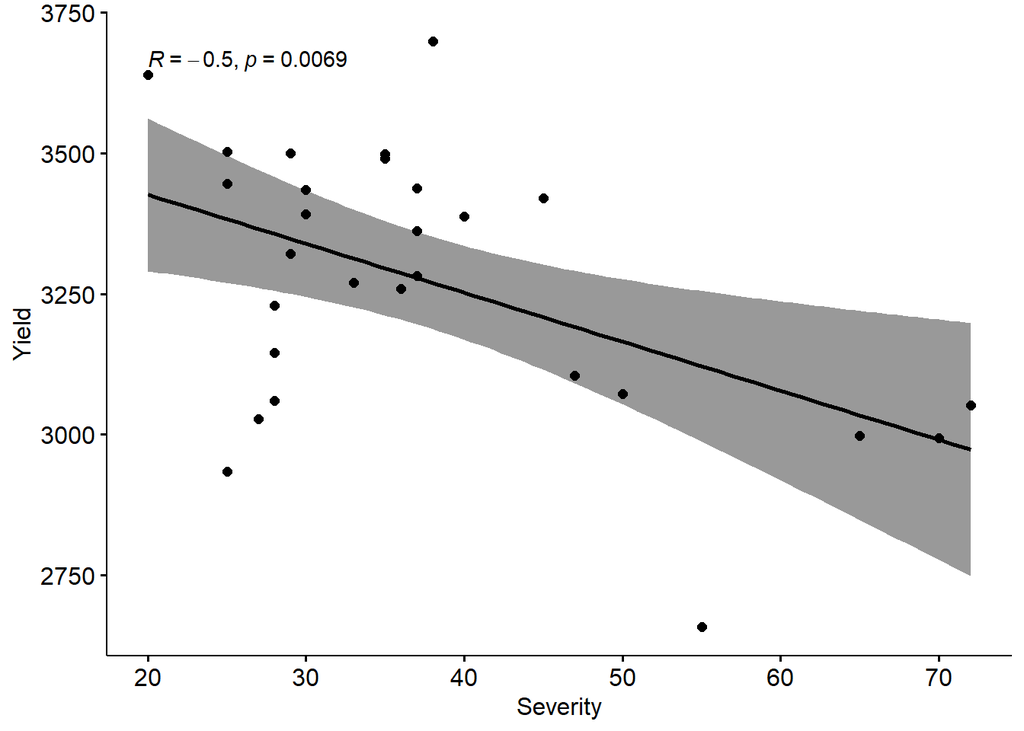

#### Visualizing the correlation between severity and yield using a scatter plot for Trial 2

```
## [1] -0.07672589
```

```
##
##  Pearson's product-moment correlation
##
## data:  trl2$sev and trl2$yld
## t = -0.39238, df = 26, p-value = 0.698
## alternative hypothesis: true correlation is not equal to 0
## 95 percent confidence interval:
##  -0.4372857  0.3050840
## sample estimates:
##         cor
## -0.07672589
```

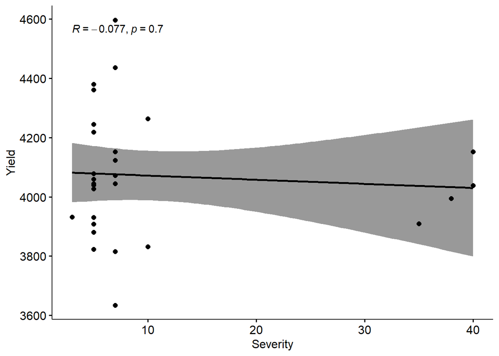

The p-value of the test is 0.698, which is greater than the significance level alpha = 0.05. We can conclude that severity and yield are not significantly correlated with a correlation coefficient of -0.07672589 and p-value of 0.698. There is almost no association between the response variables yield and severity for trial 2.

#### Visualizing the correlation between severity and yield using a scatter plot for Trial 3

```
## [1] -0.4526989
```

```
##
##  Pearson's product-moment correlation
##
## data:  trl3$sev and trl3$yld
## t = -2.5888, df = 26, p-value = 0.01557
## alternative hypothesis: true correlation is not equal to 0
## 95 percent confidence interval:
##  -0.70646059 -0.09580208
## sample estimates:
##        cor
## -0.4526989
```

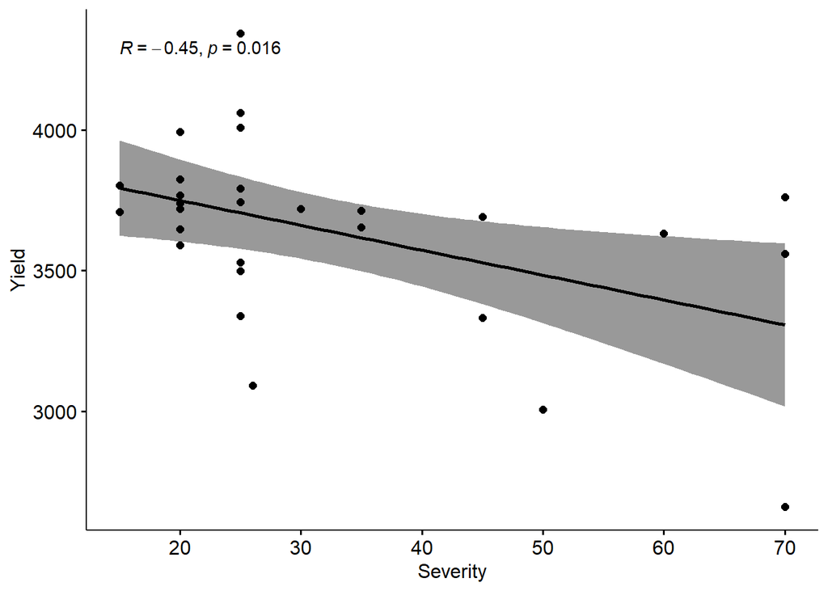

#### Visualizing the correlation between severity and yield using a scatter plot for Trial 4

```
## [1] -0.713965
```

```
##
##  Pearson's product-moment correlation
##
## data:  trl4$sev and trl4$yld
## t = -5.1994, df = 26, p-value = 1.987e-05
## alternative hypothesis: true correlation is not equal to 0
## 95 percent confidence interval:
##  -0.8583962 -0.4646556
## sample estimates:
##       cor
## -0.713965
```

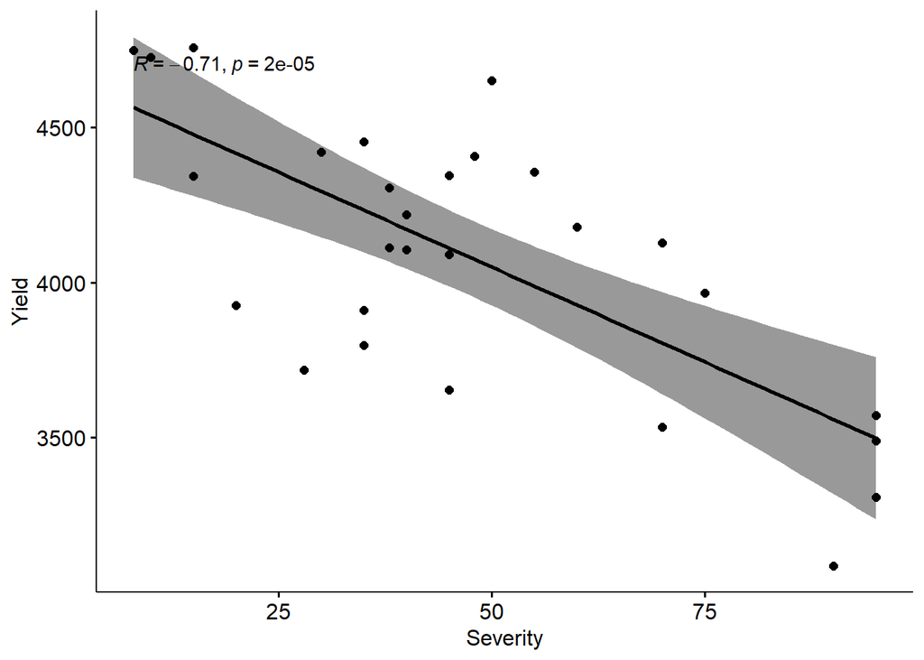